# ЕГЭ 2018 Вариант 15 EGE 2018 Variant 15

Использованы материалы:

The list of used links and books:

[ЕГЭ 2018. Математика. Профильный уровень. 20 вариантов тестов. Тематическая рабочая тетрадь.](https://drive.google.com/file/d/0B8CJrELbJAyodmtvbV8xcEtZXzA/view)

[SymPy Tutorials](http://nbviewer.jupyter.org/url/www.inp.nsk.su/~grozin/python/sympy.ipynb)

[LaTeX Mathematics](https://en.wikibooks.org/wiki/LaTeX/Mathematics)

[Метод рационализации неравенств (логарифмы)](http://internat.msu.ru/wp-content/uploads/2015/11/Metod-ratsionalizatsii-neravenstv-1.pdf)

```python
%%html
<style>
@import url('https://fonts.googleapis.com/css?family=Roboto&effect=3d|scuffed-steel|static|canvas-print|');
a, h1 h2, h3, h4, div.text_cell_render {font-family: 'Roboto'; text-shadow: 4px 4px 4px #aaa;}

h2, h3, div.output_prompt, div.output_area pre {color: slategray;}
h1, h4, div.input_prompt {color: steelblue;}
a, div.output_subarea {color: darkblue;}

span {text-shadow: 4px 4px 4px #aaa;}

body, div.output_stderr pre{background-color: aliceblue;}
div.output_stderr {background-color: slategray;}
</style>
```

```python
import numpy
import pandas
import math

import matplotlib.pyplot as plt
import matplotlib.patches as pat
from mpl_toolkits.mplot3d import Axes3D
from mpl_toolkits.mplot3d.art3d import Poly3DCollection, Line3DCollection

from __future__ import unicode_literals

import matplotlib
%matplotlib inline
```

```python
import sympy
from sympy import *
from sympy import init_printing
init_printing()
```

```python
answer_dictionary = dict()
```

## Часть 1 Part 1

[figure not shown]

### Задание 1 / Task 1

Студентами технических вузов собираются стать 18 выпускников школы. Они составляют 45% от числа выпускников.

Сколько в школе выпускников?

18 school graduates are going to become students of technical universities. They are 45% of the number of graduates.

How many graduates are there in this school?

Количество выпускников школы равно:

The number of graduates in the school is:

18 / 45 * 100 = 40

### Ответ / Answer: 40

```python
answer_dictionary[1]=str(int(18 / 0.45))
```

[figure not shown]

### Задание 2 / Task 2

На диаграмме показано число запросов со словом `ФУТБОЛ`, сделанных на некотором поисковом сайте во все месяцы с января по сентябрь 2010 года.

По горизонтали указываются месяцы, по вертикали - число запросов за данный месяц.

Определите по диаграмме, сколько было месяцев в указанный период, когда число запросов со словом `ФУТБОЛ` было меньше 3 600 000.

The diagram shows the number of queries with the word `FOOTBALL` made on some search site in all months from January to September 2010.

Months are indicated in the horizontal line, in the vertical line - the number of requests for a given month.

Determine by the diagram how many months were in the specified period, when the number of requests with the word `FOOTBALL` was less than 3 600 000.

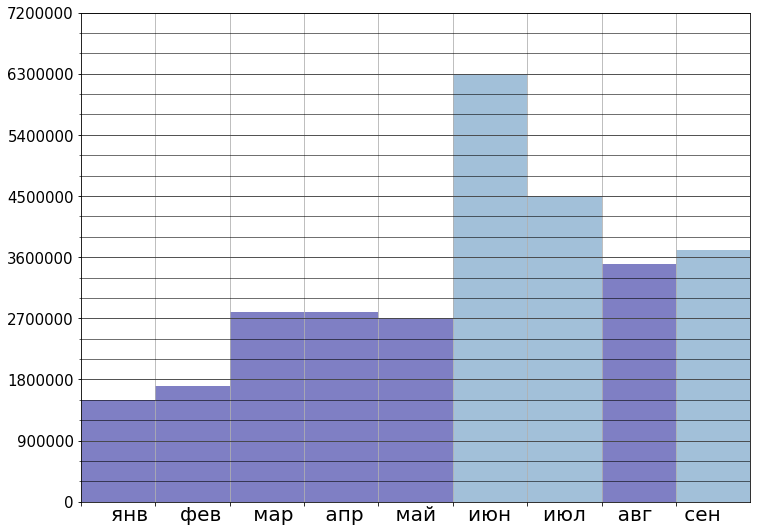

```python
months = ['янв','фев','мар','апр','май','июн','июл','авг','сен']
df=pandas.DataFrame({'months': months,
                     'queries': [15,17,28,28,27,63,45,35,37]})
fig,ax = plt.subplots()
df.plot(kind='bar', x='months', ax=ax,
        figsize=(12,9), grid=True,
        color='steelblue', alpha=0.5, align='edge', width=1)

for p in [0,1,2,3,4,7]:
    ax.patches[p].set_facecolor('darkblue')

plt.xticks(visible=False)
plt.xlabel('     '.join(months), fontsize=20)

ax.set_yticks(numpy.arange(0, 81, 9))
ax.set_yticklabels(['0','900000','1800000','2700000','3600000',
                    '4500000','5400000','6300000','7200000'], fontsize=15)
ax.set_yticks(numpy.arange(0, 81, 3), minor=True)
ax.grid(which='minor', alpha=0.7, color='black')

ax.legend().set_visible(False)

plt.xlim(0,9)
plt.ylim(0,72);
```

### Ответ / Answer: 6

```python
answer_dictionary[2]=str(6)
```

[figure not shown]

### Задание 3 / Task 3

На клетчатой бумаге с размером клетки 1 х 1 изображен треугольник. Найдите его площадь.

On a graph paper with a cell size of 1 x 1, a triangle is depicted. Find its area.

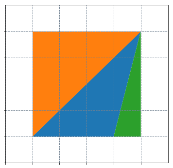

```python
plt.figure(figsize=(6,6))
plt.grid(c='slategray', ls='--', lw=1)

XY = [[[1,5,4], [1,5,1]],
      [[1,1,5], [1,5,5]],
      [[4,5,5], [1,5,1]]]
for x,y in XY:
    plt.fill(x,y)


plt.xlim(0,6)
plt.ylim(0,6)
plt.xticks(numpy.arange(0, 6, step=1), visible=False)
plt.yticks(numpy.arange(0, 6, step=1),visible=False);
```

$4^2 - \large{\frac{4^2}{2} - \frac{4 * 1}{2}}$$ = 6$

### Ответ / Answer: 6

```python
answer_dictionary[3]=str(int(4**2 - 4**2/2 - 4*1/2))
```

[figure not shown]

### Задание 4 / Task 4

Марина и Дина бросают кубик по одному разу.

Выигрывает та девочка, у которой выпадет больше очков.

Первой кубик бросила Марина, у нее выпало 3 очка.

Найдите вероятность того, что Дина выиграет.

Marina and Dina throw a die once.

The girl who has more points wins.

The first cube was thrown by Marina, she had 3 points.

Find the probability that Dina wins.

Дина выигрывает, если ей выпадет 4, 5 или 6 очков (3 варианта случайного события).

После броска у нее может быть 1, 2, 3, 4, 5 или 6 очков (6 вариантов случайного события).

Вероятность выигрыша равна 3/6 = 0.5

Dina wins if she gets 4, 5 or 6 points (3 variants of a random event).

After the throw, she can have 1, 2, 3, 4, 5 or 6 points (6 variants of a random event).

The probability of winning is 3/6 = 0.5

### Ответ / Answer: 0.5

```python
answer_dictionary[4] = str(3/6)
```

[figure not shown]

### Задание 5 / Task 5

Найдите корень уравнения:

Find the root of the equation:

$\log_{3}{(6 - 4 * x)} = 4 * log_{3}{2}$

1) Область допустимых значений: / Range of admissible values:

$6 - 4 * x > 0$

$x < 1.5$

2) Преобразования уравнения: / Equation transformations:

$\log_{3}{(6 - 4 * x)} = 4 * log_{3}{2}$

$\log_{3}{(6 - 4 * x)} = log_{3}{2^4}$

$6 - 4 * x = 16$

$4 * x = -10$

$x = -2.5$

### Ответ / Answer: -2.5

```python
answer_dictionary[5] = str(-2.5)
```

[figure not shown]

### Задание 6 / Task 6

Найдите площадь параллелограмма, если две его стороны равны 9 и 14, а угол между ними равен $30^o$.

Find the area of the parallelogram if its two sides are 9 and 14, and the angle between them is $30^o$.

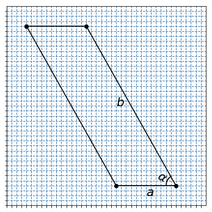

```python
f = plt.figure(figsize=(6,6))
ax = f.add_subplot(1, 1, 1, aspect=1)
ax.grid(c='steelblue', ls='--', lw=1)

ax.plot([-8,1,7,-2,-8], [8,-8,-8,8,8], '-o', c='black')

plt.text(4,-9,r'$a$', fontsize=20)
plt.text(1,0,r'$b$', fontsize=20)
plt.text(4.9,-7.3,r'$\alpha ($',
         rotation=-30,fontsize=20)

plt.xlim(-10,10)
plt.ylim(-10,10)
plt.xticks(numpy.arange(-10, 10, step=0.5), visible=False)
plt.yticks(numpy.arange(-10, 10, step=0.5), visible=False);
```

$S = a * b * sin \ \alpha$

$S = 9 * 14 * sin \ 30^o = 9 * 14 * 1/2 = 63$

### Ответ / Answer: 63

```python
answer_dictionary[6] = str(int(9 * 14 / 2))
```

[figure not shown]

### Задание 7 / Task 7

На рисунке изображены график функции $y = f'(x)$ - производной функции $f(x)$, и семь точек на оси абсцисс:

The figure shows the graph of the function $y' = f(x)$ - the derivative of the function $f(x)$, and seven points on the abscissa:

$x_1,x_2,x_3,x_4,x_5,x_6,x_7$.

В скольких из этих точек функция $f(x)$ возрастает?

In how many of these points does the function $f(x)$ increase?

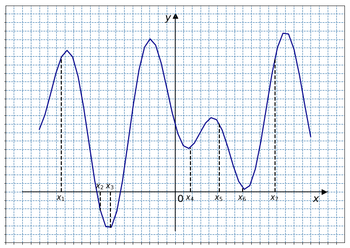

```python
f = plt.figure(figsize=(12,9))
ax = f.add_subplot(1, 1, 1, aspect=1)
ax.grid(c='steelblue', ls='--', lw=1)
ax.axhline(0, 0.05, 0.95, c='black')
ax.axvline(0, 0.05, 0.95, c='black')

def f(x,a=6.2,b=0.3,c=1.2,d=-2.1,e=+4):
    exp = (math.pow(x, 2) + math.pow(x, 5)) * (-0.1)**5
    return a * math.exp(exp) * math.cos(b*x+d) * math.sin(c*x)+e

x = numpy.linspace(-8,8)
y = [f(el) for el in x]
ax.plot(x, y, c='darkblue', lw=2)

vl = [-6.7,-4.4,-3.8,0.9,2.6,4,5.9]
for v in vl:
    ax.plot([v,v], [0,f(v)], lw=2, ls='--', c='black')

v = numpy.array([vl, [-0.5,0.2,0.2,-0.5,-0.5,-0.5,-0.5,-0.5],
                 [r'$x_1$',r'$x_2$',r'$x_3$',r'$x_4$',r'$x_5$',
                  r'$x_6$',r'$x_7$']])
for i in range(7):
    plt.text(float(v[0][i]-0.3),float(v[1][i]),v[2][i],fontsize=15)

plt.text(8.1,-0.6,r'$x$', fontsize=20)
plt.text(-0.6,10.1,r'$y$', fontsize=20)
ax.scatter(0,10.4, marker='^', s=100, c='black')
ax.scatter(8.8,0, marker='>', s=100, c='black')
plt.text(0.1,-0.6,r'$0$', fontsize=20)

plt.xlim(-10,10)
plt.ylim(-3,11)
plt.xticks(numpy.arange(-10,10, step=0.5), visible=False)
plt.yticks(numpy.arange(-3,11, step=0.5), visible=False);
```

Функция возрастает, если ее производная положительна. В данном случае производная положительна в пяти точках.

The function grows if its derivative is positive. In this case, the derivative is positive at five points.

$x_1,x_4,x_5,x_6,x_7$.

### Ответ / Answer: 5

```python
answer_dictionary[7] = str(5)
```

[figure not shown]

### Задание 8 / Task 8

Прямоугольный параллелепипед описан около сферы радиуса 4. Найдите его объем.

A rectangular parallelepiped is circumscribed around a sphere of radius 4. Find its volume.

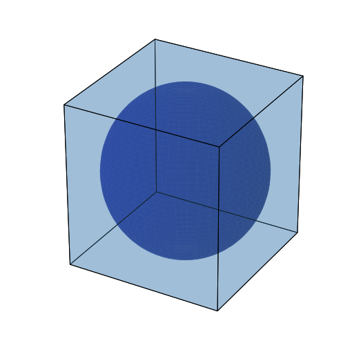

```python
f = plt.figure(figsize=(9,9))
ax = f.add_subplot(111, projection='3d')

def create_sphere(center_x,center_y,center_z,radius):
    u, v = numpy.mgrid[0:2*numpy.pi:50j, 0:numpy.pi:50j]
    x_grid = center_x + radius*numpy.cos(u)*numpy.sin(v)
    y_grid = center_x + radius*numpy.sin(u)*numpy.sin(v)
    z_grid = center_x + radius*numpy.cos(v)
    return x_grid,y_grid,z_grid

Xc,Yc,Zc = create_sphere(2.5,2.5,2.5,2.5)
ax.plot_surface(Xc, Yc, Zc, alpha=0.7, color='darkblue')

v = numpy.array([[0,0,0], [0,5,0], [5,0,0], [5,5,0],
                 [0,0,5], [0,5,5], [5,0,5], [5,5,5]])

verts = [ [v[0],v[4],v[5],v[1]],
          [v[0],v[4],v[6],v[2]],
          [v[3],v[7],v[6],v[2]],
          [v[3],v[7],v[5],v[1]],
          [v[3],v[2],v[0],v[1]],
          [v[4],v[5],v[7],v[6]]]

lines = Poly3DCollection(verts, lw=1, alpha=0.3,
                         edgecolors='black', facecolor='none')
lines.set_facecolor('steelblue')
ax.add_collection3d(lines)
plt.axis('off');
```

Прямоугольный параллелепипед, описанный около сферы, является кубом.

Его объем равен кубу длины ребра.

Ребро куба равно диаметру вписанной в него сферы.

A rectangular parallelepiped circumscribed around a sphere is a cube.

Its volume is equal to the cube of the length of the edge.

The edge of the cube is equal to the diameter of the sphere inscribed in it.

$V = a^3 = (2 * r)^3 = (2 * 4)^3 = 512$

### Ответ / Answer: 512

```python
answer_dictionary[8] = str(512)
```

[figure not shown]

### Задание 9 / Task 9

Найдите значение выражения

Find the value of the expression

$\large{\frac{36}{\cos^2 95^o + \cos^2 185^o}}$

$\large{\frac{36}{\cos^2 95^o + \cos^2 185^o}} = \frac{36}{\cos^2 95^o + \cos^2 (90^o + 95^o)} = \frac{36}{\cos^2 95^o + \sin^2 95^o} = \frac{36}{1}$ $ = 36$

```python
a = Symbol('a')
b = 36/((cos(a*pi/180))**2+(cos((a+90)*pi/180))**2)
b.subs({a:(95)})
```

$$\frac{36}{\cos^{2}{\left (\frac{17 \pi}{36} \right )} + \cos^{2}{\left (\frac{\pi}{36} \right )}}$$

```python
int(N(b.subs({a:(95)})))
```

$$36$$

### Ответ / Answer: 36

```python
answer_dictionary[9] = str(36)
```

[figure not shown]

### Задание 10 / Task 10

Зависимость температуры (в градусах Кельвина) от времени (в минутах) для нагревательного элемента некоторого прибора

была получена экспериментально и на исследуемом интервале температур задается выражением:

$T(t) = T_0 + a * t + b * t^2$, $T_0 = 900 \ K, a = 31 \ K/мин, b = -0.2 \ K/мин^2$.

Известно, что при температурах нагревателя свыше 1550 К прибор может испортиться, поэтому его нужно отключать.

Определите (в минутах), через какое наибольшее время после начала работы нужно отключать прибор.

Dependence of temperature (in degrees Kelvin) on time (in minutes) for the heating element of some device

was obtained experimentally and is determined on the investigated temperature interval by the expression:

$T(t) = T_0 + a * t + b * t^2$, $T_0 = 900 \ K, a = 31 \ K/min, b = -0.2 \ K/min^2$.

It is known that at temperatures of over 1550 K the device can be broken, so it must be turned off.

Determine (in minutes), after what the longest time after the start of work, it needs to turn off the device.

Подставим имеющиеся данные в уравнение.

Let's substitute the available data in the equation.

$1550 = 900 + 31 * t - 0.2 * t^2$

$t^2 - 155 * t + 3250 = 0$

$D = 155^2 - 4 * 3250 = 11025$

$t = \large{\frac{155 \pm \sqrt{11025}}{2}}$

$t = 25 \lor t = 130$

В ответе требовалось указать наибольший интервал времени.

Запишем меньший из корней, поскольку прибор может быть сломан после 25 минут использования.

The response required a maximum time interval.

Let's write the smaller of the roots since the device can be broken after 25 minutes of its use.

### Ответ / Answer: 25

```python
answer_dictionary[10] = str(25)
```

[figure not shown]

### Задание 11 / Task 11

Смешали 14 литров 30-процентного водного раствора некоторого вещества с 10 литрами 18-процентного раствора этого же вещества.

Сколько процентов составляет концентрация получившегося раствора?

Знак % в ответе не пишите.

14 liters of a 30% aqueous solute of a certain substance with 10 liters of an 18% solution of the same substance were mixed.

What is the concentration of the resulting solute?

It does not need to write the sign % in the answer.

Найдем отношение объема вещества в получившемся растворе ко всему объему раствора и умножим на 100 %.

Let's find the ratio of the volume of the substance in the resulting solute to the entire volume of the solute and multiply by 100%.

$100 * (0.3 * 14 + 10 * 0.18) / (14 + 10) = 25$

### Ответ / Answer: 25

```python
answer_dictionary[11] = str(int(100 * (0.3 * 14 + 10 * 0.18) / (14 + 10)))
```

[figure not shown]

### Задание 12 / Task 12

Найдите наименьшее значение функции

Find the least value of the function

$y = (x^2 - 9 * x + 9) * e^{x - 7}$

на отрезке $[6;8]$.

on the interval $[6;8]$.

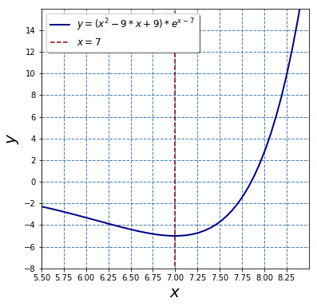

```python
f = plt.figure(figsize=(6,6))
ax = f.add_subplot(1, 1, 1)
ax.grid(c='steelblue', ls='--', lw=1)

def f(x):
    return (x ** 2 - 9 * x + 9) * math.e ** (x - 7)

x = numpy.linspace(5.5,8.5)
y = [f(el) for el in x]
ax.plot(x, y, c='darkblue', lw=2,
        label=r'$y = (x^2 - 9 * x + 9) * e^{x - 7}$')

ax.axvline(7, 0.01, 0.99, c='darkred',
           ls='--',label=r'$x=7$')

plt.xlim(5.5,8.5)
plt.ylim(-8,16)
plt.xticks(numpy.arange(5.5,8.5, step=0.25))
plt.yticks(numpy.arange(-8,16, step=2))

plt.xlabel(r'$x$', fontsize=20)
plt.ylabel(r'$y$', fontsize=20)
plt.legend(fontsize=12, shadow=True, loc=2);
```

Наименьших значений непрерывная функция может достигать в точках, где первая производная равна нулю, а вторая производная положительна.

The minimum value of a continuous function can be reached at points where the first derivative is equal to zero, and the second derivative is positive.

```python
x = Symbol('x')
y = (x ** 2 - 9 * x + 9) * E ** (x - 7)
```

```python
# производная | the first derivative
diff(y,x)
```

$$\left(2 x - 9\right) e^{x - 7} + \left(x^{2} - 9 x + 9\right) e^{x - 7}$$

```python
# производная равна нулю ∣ the first derivative is 0
solve(diff(y,x),x)
```

$$\left [ 0, \quad 7\right ]$$

```python
# вторая производная / the second derivative
diff(diff(y,x),x)
```

$$2 \left(2 x - 9\right) e^{x - 7} + \left(x^{2} - 9 x + 9\right) e^{x - 7} + 2 e^{x - 7}$$

```python
# y''(0) < 0 => max
diff(diff(y,x),x).subs({x:0})
```

$$- \frac{7}{e^{7}}$$

```python
# y''(7) > 0 => min
diff(diff(y,x),x).subs({x:7})
```

$$7$$

```python
# y(7)
y.subs({x:7})
```

$$-5$$

### Ответ / Answer: -5

```python
answer_dictionary[12] = str(y.subs({x:7}))
```

## Часть 2 Part 2

[figure not shown]

### Задание 13 / Task 13

a) Найдите корень уравнения:

a) Find the root of the equation:

$5 * \cos^2 x - 12 * \cos \ x + 4 = 0$.

б) Найдите все корни этого уравнения, принадлежащие промежутку

b) Find all the roots of this equation that belong to the interval

$\bigg[-\large{\frac{5 * \pi}{2}}$$; -\pi \bigg]$.

a)

$5 * \cos^2 x - 12 * \cos \ x + 4 = 0$

$D = 144 - 4 * 5 * 4 = 64$

$cos \ x = \large{\frac{12 \pm \sqrt{64}}{2 * 5}}$

$cos \ x = 2$$ \; \lor \; cos \ x = \large{\frac{2}{5}}$

$x \in \emptyset \; \lor \; x = \pm \arccos \frac{2}{5} \pm 2 * \pi * n; \; n \in \mathbb{N}$

б)

$-2 * \pi - arccos\frac{2}{5}; \; -2 * \pi + arccos\frac{2}{5}$

### Ответ / Answer:

#### a) $\pm \arccos \frac{2}{5} \pm 2 * \pi * n; \; n \in \mathbb{N}$;

#### б) $-2 * \pi - arccos\frac{2}{5}; \; -2 * \pi + arccos\frac{2}{5}$

```python
# check the decision method
x = Symbol('x')
g = 5 * (cos(x)) ** 2  - 12 * cos(x) + 4
```

```python
g
```

$$5 \cos^{2}{\left (x \right )} - 12 \cos{\left (x \right )} + 4$$

```python
# :)
solve(g,x)
```

$$\left [ 2 \pi - \operatorname{acos}{\left (2 \right )}, \quad - \operatorname{acos}{\left (\frac{2}{5} \right )} + 2 \pi, \quad \operatorname{acos}{\left (\frac{2}{5} \right )}, \quad \operatorname{acos}{\left (2 \right )}\right ]$$

```python
N(-5 * pi/2), N(-solve(g,x)[2] - 2 * pi), N(solve(g,x)[2] - 2 * pi), N(-pi)
```

$$\left ( -7.85398163397448, \quad -7.44246478790699, \quad -5.12390582645218, \quad -3.14159265358979\right )$$

```python
answer_dictionary[13] = 'a)±arccos(2/5)±2πn; n∈ℕ; б)−2π-arccos(2/5);−2π+arccos(2/5)'
```

[figure not shown]

### Задание 14 / Task 14

Дана правильная четырёхугольная пирамида MABCD, рёбра основания которой равны $5\sqrt{2}$.

Точка L - середина ребра MB. Тангенс угла между прямыми DM и AL равен $\sqrt{2}$.

а) Пусть O - центр основания пирамиды. Докажите, что прямые AO и LO перпендикулярны.

б) Найдите высоту данной пирамиды.

The right quadrilateral pyramid MABCD is given, the edges of the base are equal to $5\sqrt{2}$.

The point L is the midpoint of the edge MB. The tangent of the angle between the straight lines DM and AL is $\sqrt{2}$.

a) Let O be the center of the base of the pyramid. Prove that the lines AO and LO are perpendicular.

b) Find the height of this pyramid.

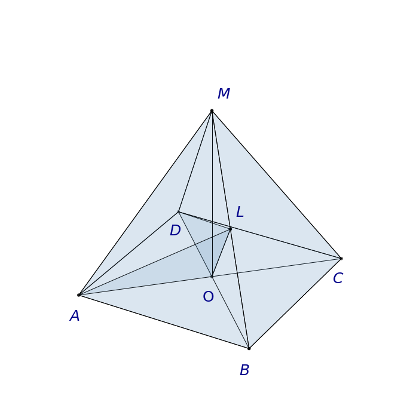

```python
f = plt.figure(figsize=(12,12))
ax = f.add_subplot(111, projection='3d')

v = numpy.array([[-1,-1,-1],[1,-1,-1],[1,1,-1],[-1,1,-1],[0,0,1],
                 [0.5,-0.5,0],[0,0,-1]])
letters = [r'$A$', r'$B$',r'$C$',r'$D$',
           r'$M$',r'$L$',r'O']

ax.scatter3D(v[:, 0],v[:, 1],v[:, 2],color='black')

verts = [ [v[0],v[1],v[4]], [v[0],v[3],v[4]],
          [v[2],v[1],v[4]], [v[2],v[3],v[4]],
          [v[0],v[1],v[2],v[3]],
          [v[4],v[6]], [v[2],v[6]], [v[1],v[6]],
          [v[0],v[5],v[6],v[0]], [v[3],v[5],v[6],v[3]] ]

piramid = Poly3DCollection(verts,lw=1,alpha=0.1,
                           edgecolors='black',facecolor='none')
piramid.set_facecolor('steelblue')
ax.add_collection3d(piramid)

for i in range(7):
    if i in [0,1,2,3,6]:
        a = -0.2
    else:
        a = 0.1
    ax.text(v[i][0],v[i][1]+a,v[i][2]+a,
            letters[i],fontsize=25,color='darkblue')

plt.axis('off');
```

а)

O - центр квадрата ABCD, MO - высота правильной пирамиды MABCD: $AO \bot BO, \; AO \bot MO. \implies$

AO перпендикулярно плоскости MOB.

LO принадлежит плоскости MOB. $\implies LO \bot AO$

O - the center of the square ABCD, MO - the height of the right pyramid MABCD: $AO \bot BO, \; AO \bot MO. \implies$

AO is perpendicular to the plane MOB.

LO belongs to the MOB plane. $\implies LO \bot AO$

б)

$\triangle MBD: DO = OB, \; BL = LM \implies MD = 2 * LO, \; LO \| MD \implies $

Угол между прямыми DM и AL равен углу AOL.

The angle between the straight lines DM and AL is equal to the angle AOL.

$AO = AC \ / \ 2 = \sqrt{AB^2 + BC^2} \ / \ 2 = \sqrt{2 * AB^2} \ / \ 2 = \sqrt{2 * (5\sqrt{2})^2} \ / \ 2$$\; = 5 \implies OD = 5$

$LO = AO \ / \ tg \angle AOL = 5 \ / \ \sqrt{2} \implies MD = 2 * 5 \ / \ \sqrt{2} = 5\sqrt{2}$

$\triangle MOD: DO \bot MO, \; MO = \sqrt{MD^2 - DO^2} = \sqrt{(5\sqrt{2})^2 - 5^2} = \sqrt{25} = 5$

### Ответ / Answer: б) 5

```python
answer_dictionary[14] ='б) 5'
```

[figure not shown]

### Задание 15 / Task 15

Решите неравенство:

Solve the inequality:

$\large{\frac{2 - (x - 6)^{-1}}{5 * (x - 6)^{-1} - 1}}$$\leq -0.2$

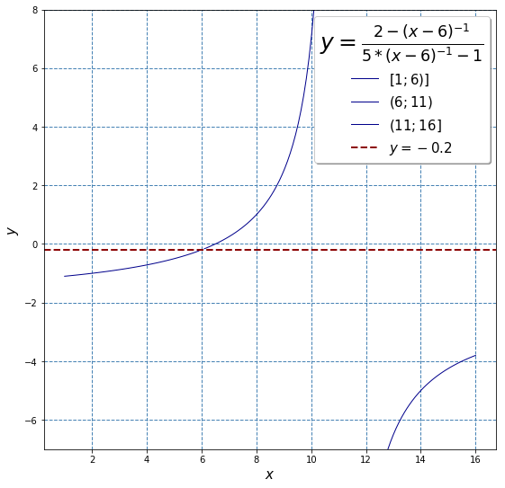

```python
f = plt.figure(figsize=(9,9))
ax = f.add_subplot(1, 1, 1)
ax.grid(c='steelblue', ls='--', lw=1)

x1 = numpy.linspace(1,5.9)
y1 = [(2 - 1/(el - 6))/(5 / (el - 6) - 1) for el in x1]
x2 = numpy.linspace(6.1,10.9)
y2 = [(2 - 1/(el - 6))/(5 / (el - 6) - 1) for el in x2]
x3 = numpy.linspace(11.1,16)
y3 = [(2 - 1/(el - 6))/(5 / (el - 6) - 1) for el in x3]

ax.plot(x1, y1, c='darkblue', lw=1,
        label=r'$[1;6)]$')
ax.plot(x2, y2, c='darkblue', lw=1,
        label=r'$(6;11)}$')
ax.plot(x3, y3, c='darkblue', lw=1,
        label=r'$(11;16]}$')

ax.axhline(-0.2, c='darkred',ls='--',lw=2,label=r'$y = -0.2$')

plt.xlabel(r'$x$', fontsize=15)
plt.ylabel(r'$y$', fontsize=15)
plt.ylim(-7,8)

ax.legend(title=r'$y = \frac{2 - (x - 6)^{-1}}{5 * (x - 6)^{-1} - 1}$',
          fontsize=15, shadow=True)
ax.get_legend().get_title().set_fontsize(25);
```

1) Область допустимых значений / Range of admissible values

$ \begin{cases} x - 6 \neq 0 \\ 5 * (x - 6)^{-1} - 1 \neq 0 \end{cases} \iff \begin{cases} x \neq 6 \\ x \neq 11 \end{cases}$

2) Преобразования неравенства / Inequality transformations

$\large{\frac{2 - (x - 6)^{-1}}{5 * (x - 6)^{-1} - 1}}$$\leq -0.2$

$\large{\frac{2 * (x - 6) - 1}{5 - (x - 6)}}$$ \leq -0.2$

$\large{\frac{2 * x - 13}{11 - x}}$$ \leq -0.2$

$ \begin{cases} x < 11 \\ 2 * x - 13 \leq -0.2 * (11 - x) \end{cases} \lor \begin{cases} x > 11 \\ 2 * x - 13 \geq -0.2 * (11 - x) \end{cases} \iff \\ \begin{cases} x < 11 \\ 1.8 * x \leq 10.8 \end{cases} \lor \begin{cases} x > 11 \\ 1.8 * x \geq 10.8 \end{cases} \iff \begin{cases} x < 11 \\ x \leq 6 \end{cases} \lor \begin{cases} x > 11 \\ x \geq 6 \end{cases}$

$x \leq 6 \lor x > 11$

3) 1), 2) $\implies x \in (-\infty;6) \cup (11;+\infty)$

### Ответ / Answer: $(-\infty;6) \cup (11;+\infty)$

```python
answer_dictionary[15] ='(−∞;6)∪(11;+∞)'
```

[figure not shown]

### Задание 16 / Task 16

Окружности с центрами O и B радиуса OB пересекаются в точке C.

Радиус OA окружности с центром O перпендикулярен OB, причем точки A и C лежат по одну сторону от прямой OB.

Окружность $S_1$ касается меньших дуг AC и OC этих окружностей, а также отрезка OA.

Окружность $S_2$ касается окружности с центром B, прямой OA и окружности $S_1$.

а) Докажите, что прямая OA касается окружности с центром B.

б) Найдите отношение радиуса окружности $S_1$ к радиусу окружности $S_2$.

Circles with the centers O and B of the radius OB intersect at the point C.

The radius OA of a circle with the center O is perpendicular to OB, and the points A and C lie on one side of the line OB.

The circle $S_1$ is tangent to the smaller arcs AC and OC of these circles, as well as the segment OA.

The circle $S_2$ is tangent to a circle with the center B, the line OA and the circle $S_1$.

a) Prove that the line OA is tangent to the circle with the center B.

b) Find the ratio of the radius of the circle $S_1$ to the radius of the circle $S_2$.

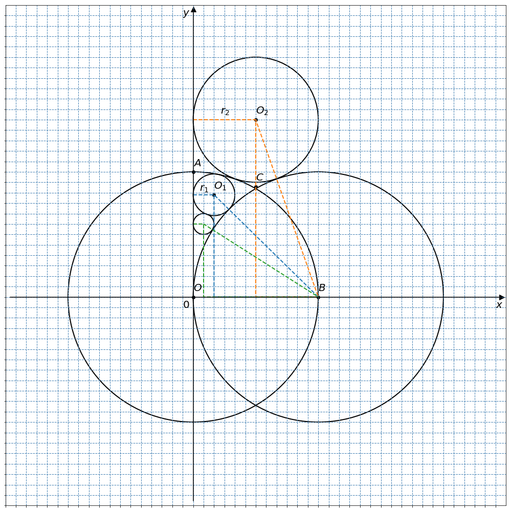

```python
f = plt.figure(figsize=(18,18))
ax = f.add_subplot(1, 1, 1, aspect=1)
ax.grid(c='steelblue', ls='--', lw=1)

XYR = [[-3,3,-2,0,-2.5],
       [0,0,4.9,8.5,3.5],
       [6,6,1,3,0.5]]

for i in range(5):
    circle = pat.Circle((XYR[0][i],XYR[1][i]),XYR[2][i],
                        lw=2,edgecolor='black',facecolor='none')
    ax.add_artist(circle)

for i in range(2,5):
    ax.plot([-3,XYR[0][i],XYR[0][i],XYR[0][1],XYR[0][i]],
            [XYR[1][i],XYR[1][i],0,XYR[1][1],XYR[1][i]],
            ls='--',lw=2)

XYL = [[-3,-3,3,0,-2,0],
       [0,6,0,5.3,4.9,8.5],
       [r'$O$',r'$A$',r'$B$',r'$C$',r'$O_1$',r'$O_2$']]

for i in range(6):
    plt.text(XYL[0][i],XYL[1][i]+0.3,
             XYL[2][i],fontsize=20)
    plt.scatter(XYL[0][i],XYL[1][i],c='black')

plt.text(-2.7,5.1,r'$r_1$', fontsize=20)
plt.text(-1.7,8.8,r'$r_2$', fontsize=20)

ax.axhline(0,0.01,0.99,c='black')
ax.axvline(-3,0.01,0.99,c='black')
plt.scatter(-3,13.8, marker='^', s=100, c='black')
plt.scatter(11.8,0, marker='>', s=100, c='black')
plt.text(11.5,-0.5,r'$x$', fontsize=20)
plt.text(-3.5,13.5,r'$y$', fontsize=20)
plt.text(-3.5,-0.5,r'$0$', fontsize=20)

plt.xlim(-12,12)
plt.ylim(-10,14)
plt.xticks(numpy.arange(-12,12,step=0.5),visible=False)
plt.yticks(numpy.arange(-10,14,step=0.5),visible=False);
```

1)

Для решения задачи построим координатную плоскость с

- осью абсцисс $OB$,
- осью ординат $OA$,
- единичным отрезком $OB$,
- началом координат в точке $O$.

Точка $B$ в данной системе имеет координаты (1;0), $A$ - (0;1); $OA = OB = 1$.

Обозначим $[O_1 (x_1;y_1), r_1], [O_2 (x_2;y_2), r_2]$ - центры и радиусы окружностей $S_1, S_2$ соответственно.

$OA$ - касательная к $S_1, S_2 \implies r_1, r_2 \bot OA; r_1, r_2 \| OB \implies r_1 = x_1, r_2 = x_2$.

To solve the problem, let's construct the coordinate plane with

- the axis of abscissas $OB$,
- the axis of ordinates of $OA$,
- the single segment $OB$,
- the origin at the $O$ point.

The point $B$ in this system has coordinates (1; 0), $A$ - (0; 1); $OA = OB = 1$.

Let's denote $[O_1 (x_1;y_1), r_1], [O_2 (x_2;y_2), r_2]$ the centers and the radii of the circles $S_1, S_2$ respectively.

$OA$ - the tangent line to $S_1, S_2 \implies r_1, r_2 \bot OA; r_1, r_2 \| OB \implies r_1 = x_1, r_2 = x_2$.

2)

$S_1$ касается внутренним образом окружности с центром в точке $O$ и расстояние $OO_1$ равно разности радиусов: $OO_1 = 1 - r_1 = 1 - x_1$.

$S_1$ касается внешним образом окружности с центром в точке $B$ и расстояние $BO_1$ равно сумме радиусов: $BO_1 = 1 + r_1 = 1 + x_1$.

$S_2$ касается внешним образом окружности с центром в точке $B$ и расстояние $BO_2$ равно сумме радиусов: $BO_2 = 1 + r_2 = 1 + x_2$.

$S_1$ touches internally the circle centered at $O$ and the distance $OO_1$ is equal to the difference of radii: $OO_1 = 1 - r_1 = 1 - x_1$.

$S_1$ touches externally the circle centered at $B$ and the distance $BO_1$ is equal to the sum of radii: $BO_1 = 1 + r_1 = 1 + x_1$.

$S_2$ touches externally the circle centered at $B$ and the distance $BO_2$ is equal to the sum of radii: $BO_2 = 1 + r_2 = 1 + x_2$.

В выбранной координатной плоскости

In the selected coordinate plane

- $OO_1^2 = x_1^2 + y_1^2$
- $O_1O_2^2 = (x_1 - x_2)^2 + (y_1 - y_2)^2$
- $BO_1^2 = (1 - x_1)^2 + y_1^2$
- $BO_2^2 = (1 - x_2)^2 + y_2^2$
- $y_1 > 0, y_2 > 0$

$x_1^2 + y_1^2 = (1 - x_1)^2 \implies y_1^2 = 1 - 2 * x_1$

$(1 - x_1)^2 + y_1^2 = (1 + x_1)^2 \implies y_1^2 = 4 * x_1 \implies y_1 = 2 * \sqrt{x_1}$

$(1 - x_2)^2 + y_1^2 = (1 + x_2)^2 \implies y_2^2 = 4 * x_2 \implies y_2 = 2 * \sqrt{x_2}$

$4 * x_1 = 1 - 2 * x_1 \implies x_1 = r_1 = \frac{1}{6}$

3)

Если $S_1, S_2$ касаются внутренним образом и расстояние между их центрами $O_1O_2$ определяется как разность радиусов, то:

If $S_1, S_2$ touch internally and the distance $O_1O_2$ is equal to the difference of radii then:

$(x_1 - x_2)^2 + (y_1 - y_2)^2 = (r_1 - r_2)^2 = (x_1 - x_2)^2 \implies (y_1 - y_2)^2 = 0 \implies y_1^2 = y_2^2 \implies y_1 = y_2, x_1 = x_2 \implies S_1 \equiv S_2$.

Если $S_1, S_2$ касаются внешним образом и расстояние между их центрами $O_1O_2$ определяется как сумма радиусов, то:

If $S_1, S_2$ touch externally and the distance $O_1O_2$ is equal to the sum of radii then:

$(x_1 - x_2)^2 + (y_1 - y_2)^2 = (r_1 + r_2)^2 = (x_1 + x_2)^2 \iff$

$(y_1 - y_2)^2 = 4 * x_1 * x_2 \iff y_1 - y_2 = \pm 2 * \sqrt{x_1 * x_2} \iff $

$\sqrt{x_1} - \sqrt{x_2} = \pm \sqrt{x_1 * x_2} \iff \sqrt{x_2} * (1 \pm \sqrt{x_1}) = \sqrt{x_1} \iff x_2 = \large{\frac{x_1}{(1 \pm \sqrt{x_1})^2}}$

$\large{\frac{x_1}{x_2}}$ $= (1 \pm \sqrt{x_1})^2 = (1 \pm \sqrt{1/6})^2 = \large{\frac{7 \pm 2\sqrt{6}}{6}}$

### Ответ / Answer: $\frac{7 \pm 2\sqrt{6}}{6}$

```python
answer_dictionary[16] ='(7±2√6)/6'
```

[figure not shown]

### Задание 17 / Task 17

В двух областях есть по 20 рабочих, каждый из которых готов трудиться по 10 часов в сутки на добыче алюминия и никеля.

В первой области один рабочий за час добывает 0.2 кг алюминия или 0.2 кг никеля.

Во второй области для добычи $x$ кг алюминия в день требуется $x^2$ человеко-часов труда,

а для добычи $y$ кг никеля в день требуется $y^2$ человеко-часов труда.

Обе области поставляют добытый металл на завод, где для нужд промышленности производится сплав алюминия и никеля,

в котором на 1 кг алюминия приходится 2 кг никеля.

При этом области договариваются между собой вести добычу металлов так, чтобы завод мог произвести наибольшее количество сплава.

Сколько килограммов сплава при таких условиях ежедневно сможет произвести завод?

In two regions there are 20 workers, each of which is ready to work 10 hours a day on the extraction of aluminum and nickel.

In the first region, one worker per hour produces 0.2 kg of aluminum or 0.2 kg of nickel.

In the second region, $x^2$ man-hours of labor are required to produce $x$ kg of aluminum per day,

and $y^2$ man-hours of labor are required to extract $y$ kg of nickel per day.

Both regions supply the extracted metal to the factory, where for the needs of industry an aluminum and nickel alloy is produced,

in which 1 kg of aluminum accounts for 2 kg of nickel.

At the same time, the regions agree to conduct mining of metals among themselves so that the factory can produce the greatest amount of alloy.

How many kilograms of alloy under such conditions can a factory produce daily?

1) В первом регионе наибольшее количество металла можно добыть, используя труд всех рабочих по 10 часов в день:

1) In the first region, the greatest amount of metal can be extracted, using the labor of all workers for 10 hours a day:

$0.2 * 10 * 20 = 40$.

Пусть $m $- количество добытого в этом регионе алюминия, $40 - m$ никеля.

Let $m$ be the amount of aluminum mined in this region, $40 - m$ - the amount of nickel.

2) Рассмотрим второй регион.

2) Let's have a look on the second region.

Пусть $n$ - количество рабочих, добывающих алюминий, $20 - n$ - добывающих никель.

Le'ts denote $n$ - the number of workers producing aluminum, $20 - n$ - producing nickel.

Количество добытого алюминия равно $\sqrt{10 * n}$, никеля - $\sqrt{10 * (20 - n)}$.

The amount of aluminum mined in this region is $\sqrt{10 * n}$, $\sqrt{10 * (20 - n)}$ - the amount of nickel.

3) В двух областях количество добытого алюминия равно $m + \sqrt{10 * n}$, никеля - $40 - m + \sqrt{200 - 10 * n}$.

3) The amount of aluminum mined in two regions is $m + \sqrt{10 * n}$, $40 - m + \sqrt{200 - 10 * n}$- the amount of nickel.

Количество никеля должно быть в два раза больше.

The amount of nickel should be two times greater.

$2 * m + 2 * \sqrt{10 * n} = 40 - m + \sqrt{200 - 10 * n}$

$m = (\sqrt{200 - 10 * n} - 2 * \sqrt{10 * n} + 40) / 3$

4) Количество сплава равно утроенному количеству алюминия.

4) The amount of alloy is equal to the tripled amount of aluminum.

$f(n) = 3 * (m + \sqrt{10 * n}) = \sqrt{200 - 10 * n} - 2 * \sqrt{10 * n} + 40 + 3 * \sqrt{10 * n} = \sqrt{200 - 10 * n} + \sqrt{10 * n} + 40$

$f(n) \to max, n < 20, n \in \mathbb{N}$

$f'(n) = \large{\frac{10}{2 * \sqrt{10 * n}} - \frac{10}{2 * \sqrt{200 - 10 * n}}}$

$f'(n) = 0 \iff 200 - 10 * n = 10 * n \iff n = 10$

$f(10) = \sqrt{200 - 10 * 10} + \sqrt{10 * 10} + 40 = 60$

### Ответ / Answer: 60

```python
answer_dictionary[17] ='60'
```

[figure not shown]

### Задание 18 / Task 18

Найдите все значения параметра $k$, при каждом из которых уравнение

Find all values of the parameter $k$, for each of which the equation

$\large{\frac{2 - (4 - 4 * k) * \sin t}{\cos t - 4 * \sin t}}$$ = 1$

имеет хотя бы одно решение на отрезке $\bigg[-3\pi; -\large{\frac{5\pi}{2}}\bigg]$.

has at least one solution on the interval.

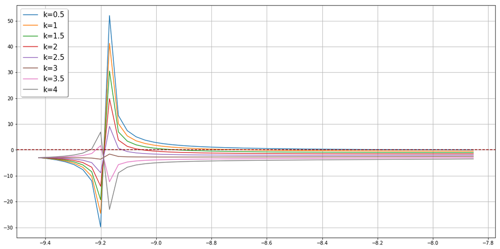

```python
def F(x,k): return (2 - (4 - 4 * k) * math.sin(x))/(math.cos(x) - 4 * math.sin(x)) - 1
X = numpy.linspace(-3*math.pi, -5*math.pi/2)

plt.figure(figsize=(18,9))
for k in [0.5, 1, 1.5, 2, 2.5, 3, 3.5, 4]:
    plt.plot(X, [F(x,k) for x in X], label='k='+str(k))

plt.axhline(0, c='darkred', ls='--')
plt.legend(shadow=True, loc=2, fontsize=15)
plt.grid(True)
```

1) Область допустимых значений / Range of admissible values

I. $\cos t - 4 * \sin t \neq 0$

$4 * \sin t \neq \cos t$

$16 * \sin^2 t \neq \cos^2 t$

$16 * \sin^2 t \neq 1 - \sin^2 t$

$\sin t \neq -\frac{1}{\sqrt{17}}$

$\cos t \neq - \sqrt{1 - (\frac{1}{\sqrt{17}})^2}$

$\cos t \neq -\frac{4}{\sqrt{17}}$

II. $-1 \leq \sin t \leq 0; -1 \leq \cos t \leq 0; \; \forall t \in$$\bigg[-3\pi; -\large{\frac{5\pi}{2}}\bigg]$.

III. $\cos^2 t + \sin^2 t = 1$

2) Преобразования уравнения / The transformations of the equation

$\large{\frac{2 - (4 - 4 * k) * \sin t}{\cos t - 4 * \sin t}}$$ = 1$

$2 - (4 - 4 * k) * \sin t = \cos t - 4 * \sin t$

$\cos t = 4 * k * \sin t + 2 \; (*)$

3)

$(*)$ задает на плоскости с координатами $(\sin t, \cos t )$ группу прямых, проходящих через точку (0;2).

Исходное уравнение имеет одно решение, если эти прямые

- пересекают единичную окружность $\cos^2 t + \sin^2 t = 1$,
- точки пересечения лежат в третьей координатной четверти $-1 \leq \sin t \leq 0; -1 \leq \cos t \leq 0$.

Для удобства вычислений в данной задаче $\sin t$ отмечени на оси абсцисс, $\cos t $ - на оси ординат.

$(*)$ defines on the plane with coordinates $(\sin t, \cos t)$ the group of lines passing through the point (0; 2).

The original equation has one solution if these lines

- intersect the unit circle $\cos^2 t + \sin^2 t = 1$,
- the intersection points lie in the third coordinate quarter $-1 \leq \sin t \leq 0; -1 \leq \cos t \leq 0$.

For convenience of calculations in the given problem $\sin t$ marks on the abscissa, $\cos t$ - on the ordinate axis.

4)

Определим $k$ для случая, когда решений нет: $\cos t - 4 * \sin t = 0$.

Let's define $k$ for the case when there are no solutions: $\cos t - 4 * \sin t = 0$.

$-\frac{4}{\sqrt{17}} = 4 * k * (-\frac{1}{\sqrt{17}}) + 2$

$\frac{4}{\sqrt{17}} + 2 = 4 * k * \frac{1}{\sqrt{17}}$

$k = 1 + \frac{\sqrt{17}}{2}$

$\cos t = (4 + 2\sqrt{17}) * \sin t + 2$

5)

Определим $k$ для точки (-1;0):

Let's define $k$ for the point (-1;0):

$\; 0 = 4 * k * (-1) + 2 \iff k = 0.5$.

$\cos t = 2 * \sin t + 2$

При любом $k \geq 0.5$ (за исключением пункта 4) ) прямая вида $(*)$ пересечет единичную окружность в третьей координатной четверти.

For any $k \geq 0.5$ (except for item 4) ), a line of the form $(*)$ intersects the unit circle in the third coordinate quarter.

$k = 1 \implies \cos t = 4 * \sin t + 2$

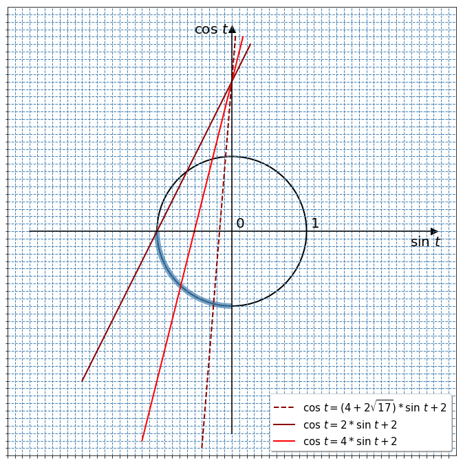

```python
f = plt.figure(figsize=(12,12))
ax = f.add_subplot(1, 1, 1, aspect=1)
ax.grid(c='steelblue', ls='--', lw=1)

circle = pat.Circle((0, 0), 1, lw=2,
                edgecolor='black', facecolor='none')
arc = pat.Arc((0, 0), 2, 2, lw=8, alpha=0.7,
              theta1=180, theta2=270,
              edgecolor='steelblue',
              facecolor='none')
ax.add_artist(circle)
ax.add_artist(arc)

ax.plot([0.05,-0.4],[2.2+0.1*17**0.5,0.4-0.8*17**0.5],
        ls='--',lw=2,c='darkred',label=r'$\cos \ t = (4 + 2\sqrt{17}) * \sin \ t + 2$')
ax.plot([-2,0.25],[-2,2.5],ls='-',lw=2,c='darkred',
        label=r'$\cos \ t = 2 * \sin \ t + 2$')
ax.plot([-1.2,0.15],[-2.8,2.6],ls='-',lw=2,c='red',
        label=r'$\cos \ t = 4 * \sin \ t + 2$')

ax.axhline(0,0.05,0.95,c='black')
ax.axvline(0,0.05,0.95,c='black')
plt.text(0.05,0.05,r'$0$', fontsize=20)
plt.text(1.05,0.05,r'$1$', fontsize=20)

plt.text(2.38,-0.19,r'$\sin \ t$', fontsize=20)
plt.text(-0.5,2.65,r'$\cos \ t$', fontsize=20)
ax.scatter(0,2.71, marker='^', s=100, c='black')
ax.scatter(2.71,0, marker='>', s=100, c='black')

plt.legend(shadow=True, loc=4, fontsize=15)
plt.xlim(-3,3)
plt.ylim(-3,3)
plt.xticks(numpy.arange(-3, 3, step=0.1), visible=False)
plt.yticks(numpy.arange(-3, 3, step=0.1), visible=False);
```

### Ответ / Answer: $[\frac{1}{2}; 1+\frac{\sqrt{17}}{2}) \cup (1+\frac{\sqrt{17}}{2}; +\infty)$

```python
answer_dictionary[18] ='[1/2;1+√17/2)∪(1+√17/2;+∞)'
```

[figure not shown]

### Задание 19 / Task 19

Дана убывающая арифметическая прогрессия

$a_1 = \large{\frac{6 * m - m^2 - 9}{6 * m - m^2}}$, $a_2 = \large{\frac{6 * m - m^2 - 12}{6 * m - m^2}}$, ..., $a_n = \large{\frac{-10}{6 * m - m^2}}$,

которая состоит более чем из двух членов.

а) Может ли число $m$ быть больше 8?

б) Может ли в прогрессии $a_1, a_2, ..., a_n$ быть ровно 5 членов?

в) Найдите все возможные значения суммы данной прогрессии.

A decreasing arithmetic progression is given

$a_1 = \large{\frac{6 * m - m^2 - 9}{6 * m - m^2}}$, $a_2 = \large{\frac{6 * m - m^2 - 12}{6 * m - m^2}}$, ..., $a_n = \large{\frac{-10}{6 * m - m^2}}$,

and it consists of more than two members.

a) Can the number $m$ be greater than 8?

b) Can there be exactly 5 terms in the progression $a_1, a_2, ..., a_n$?

c) Find all possible values of the sum of this progression.

а)

$a_1 = \large{\frac{6 * m - m^2 - 9}{6 * m - m^2}} = \frac{m^2 - 6 * m + 9}{m^2 - 6 * m} = 1 + \frac{9}{m^2 - 6 * m}$

$a_2 = \large{\frac{6 * m - m^2 - 12}{6 * m - m^2}} = 1 + \frac{12}{m^2 - 6 * m}$

...

$a_n = -\large{\frac{10}{6 * m - m^2}} = \frac{10}{m^2 - 6 * m}$

$a_1 > a_2$

$\large{1 + \frac{9}{m^2 - 6 * m} > 1 + \frac{12}{m^2 - 6 * m}}$

$\large{\frac{m^2 - 6 * m}{9} < \frac{m^2 - 6 * m}{12}}$

$4 * (m^2 - 6 * m) < 3 * (m^2 - 6 * m)$

$m^2 - 6 * m < 0 \; (*)$

$0 < m < 6$

$m = 8 \notin (0;6)$

Последовательность чисел не образует убывающую арифметическую прогрессию.

The sequence of numbers does not form a decreasing arithmetic progression.

б)

$a_2 - a_1 = 1 + \large{\frac{12}{m * (m - 6)}}$$ - 1 - \large{\frac{9}{m * (m - 6)} = \frac{3}{m * (m - 6)}}$

$n = 5$

$a_5 = 1 + \large{\frac{21}{m^2 - 6 * m}} = \frac{10}{m^2 - 6 * m}$

$m^2 - 6 * m + 11 = 0$

$D = 6^2 - 4 * 11 = -8 < 0$

$m \in \emptyset$

$n = 6$

$a_6 = 1 + \large{\frac{24}{m^2 - 6 * m}} = \frac{10}{m^2 - 6 * m}$

$m^2 - 6 * m + 14 = 0$

$D = 6^2 - 4 * 14 = -20 < 0$

$m \in \emptyset$

...

$a_n = 1 + \large{\frac{3 * (n - 1) + 9}{m^2 - 6 * m}} = \frac{10}{m^2 - 6 * m}$

$m^2 - 6 * m + 3 * n - 4 = 0$

$D = 6^2 - 4 * (3 * n - 4) = 52 - 12 * n < 0 \; \forall n > 4, \; n \in \mathbb{N}$

$m \in \emptyset \; \forall n > 4, \; n \in \mathbb{N}$

в)

n = 3

$a_3 = 1 + \large{\frac{15}{m^2 - 6 * m}} = \frac{10}{m^2 - 6 * m}$

$m^2 - 6 * m + 5 = 0$

$D = 6^2 - 4 * 5 = 16$

$m = 1, m = 5$

$a_1 = 1 + \frac{9}{1^2 - 6 * 1} = -0.8$

$a_2 = 1 + \frac{12}{1^2 - 6 * 1} = -1.4$

$a_3 = \frac{10}{1^2 - 6 * 1} = -2$

$a_1 + a_2 + a_3 = -4.2$

n = 4

$a_4 = 1 + \large{\frac{18}{m^2 - 6 * m}} = \frac{10}{m^2 - 6 * m}$

$m^2 - 6 * m + 8 = 0$

$D = 6^2 - 4 * 8 = 4$

$m = 2, m = 4$

$a_1 = 1 + \frac{9}{2^2 - 6 * 2} = -0.125$

$a_2 = 1 + \frac{12}{2^2 - 6 * 2} = -0.5$

$a_3 = 1 + \frac{15}{2^2 - 6 * 2} = -0.875$

$a_4 = \frac{10}{2^2 - 6 * 2} = -1.25$

$a_1 + a_2 + a_3 + a_4 = -2.75$

### Ответ / Answer: а) нет; б) нет; в) -21/5; -11/4

```python
answer_dictionary[19] ='а) нет; б) нет; в)-4.2;-2.75.'
```

## Ответы / Answers

| 1 | 2 | 3 | 4 | 5 | 6 | 7 | 8 | 9 | 10 | 11 | 12 |
| --- | --- | --- | --- | --- | --- | --- | --- | --- | --- | --- | --- |
| 40 | 6 | 6 | 0.5 | -2.5 | 63 | 5 | 512 | 36 | 25 | 25 | -5 |

| 13 | 14 | 15 | 16 | 17 | 18 | 19 |
| --- | --- | --- | --- | --- | --- | --- |
| a) $\pm \arccos \frac{2}{5} \pm 2 * \pi * n;$ $ \; n \in \mathbb{N}$; б) $-2 * \pi - arccos\frac{2}{5};$ $ \; -2 * \pi + arccos\frac{2}{5}$ | б) 5 | (−∞;6)∪(11;+∞) | $\frac{7 \pm 2\sqrt{6}}{6}$ | 60 | $[\frac{1}{2}; 1 + \frac{\sqrt{17}}{2}) \cup (1 + \frac{\sqrt{17}}{2}; +\infty)$ | а) нет; б) нет; в)-4.2;-2.75 |

```python
answer_dictionary
```

```
{1: '40',
 2: '6',
 3: '6',
 4: '0.5',
 5: '-2.5',
 6: '63',
 7: '5',
 8: '512',
 9: '36',
 10: '25',
 11: '25',
 12: '-5',
 13: 'a)±arccos(2/5)±2πn; n∈ℕ; б)−2π-arccos(2/5);−2π+arccos(2/5)',
 14: 'б) 5',
 15: '(−∞;6)∪(11;+∞)',
 16: '(7±2√6)/6',
 17: '60',
 18: '[1/2;1+√17/2)∪(1+√17/2;+∞)',
 19: 'а) нет; б) нет; в)-4.2;-2.75.'}
```

[figure not shown]